# Reproducible Research: Peer Assessment 1

Fernanda Sánchez

7/28/2020

# Loading and preprocessing the data

```r
library(data.table)
library(ggplot2)

## Load dataset and unzip it
url <- "https://d396qusza40orc.cloudfront.net/repdata%2Fdata%2Factivity.zip"
download.file(url, destfile = paste(getwd(), "repdata.zip", sep = "/"), method = "curl")
unzip("repdata.zip")

## Read data.
activityDT <- fread(input = "activity.csv")
```

# What is mean total number of steps taken per day?

### 1. Calculate the total number of steps taken per day

```r
totalSteps <- aggregate(activityDT$steps, by=list(date=activityDT$date), FUN=sum)
head(totalSteps)
```

```
##         date     x
## 1 2012-10-01    NA
## 2 2012-10-02   126
## 3 2012-10-03 11352
## 4 2012-10-04 12116
## 5 2012-10-05 13294
## 6 2012-10-06 15420
```

### 2.Make a histogram of the total number of steps taken each day

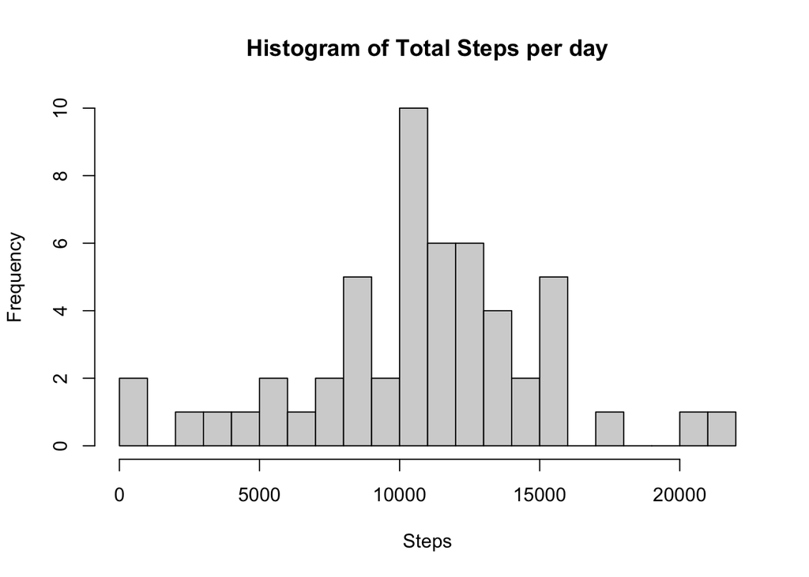

```r
hist(totalSteps$x,
     breaks=20,
     main="Histogram of Total Steps per day",
     xlab="Steps")
```

```r
mean <- mean(totalSteps$x, na.rm = TRUE)
median <- median(totalSteps$x, na.rm = TRUE)
```

# What is the average daily activity pattern?

### 1. Make a time series plot (i.e. type = "l") of the 5-minute interval (x-axis) and the average number of steps taken, averaged across all days (y-axis)

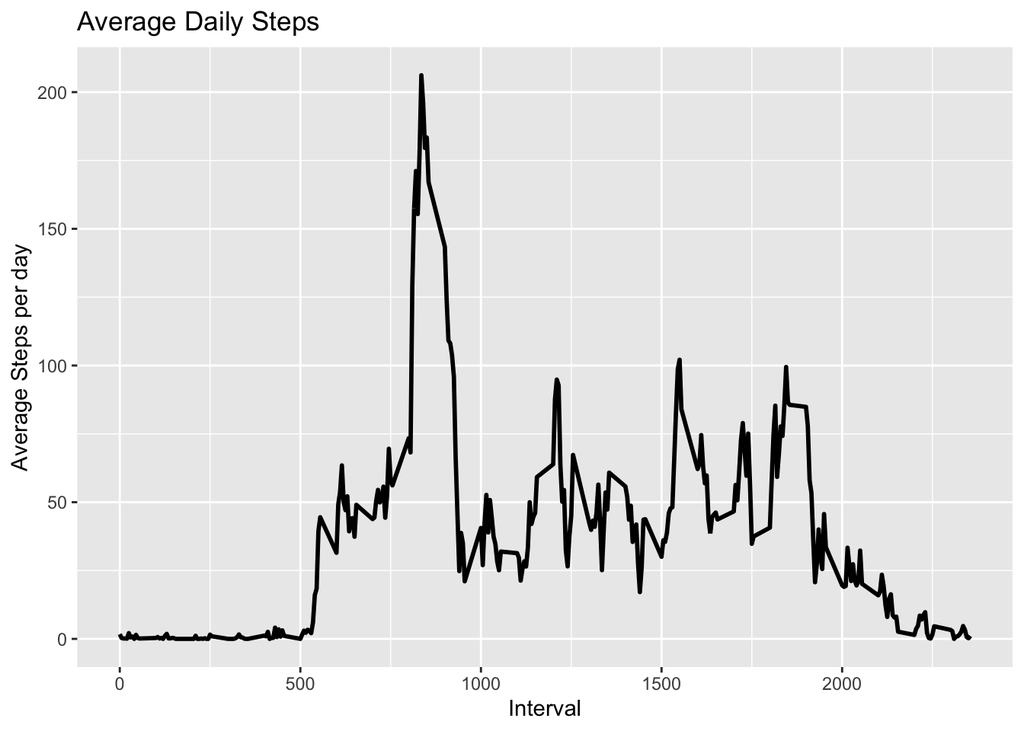

```r
intervalDT <- aggregate(activityDT$steps, by=list(interval=activityDT$interval), FUN=mean, na.rm=TRUE)
names(intervalDT)[2] <- "steps"

ggplot(intervalDT, aes(x = interval , y = steps)) +
  geom_line(size=1) +
  labs(title = "Average Daily Steps", x = "Interval", y = "Average Steps per day")
```

### 2. Which 5-minute interval, on average across all the days in the dataset, contains the maximum number of steps?

```r
maxim <- intervalDT[intervalDT$steps == max(intervalDT$steps),]
```

On average across all the days in the dataset, the 5-minute interval containing the maximum number of steps is 835, 206.1698113.